# Homework_7

Megan O’Connor

2024-02-28

**1. Think about an ongoing study in your lab (or a paper you have read in a different class), and decide on a pattern that you might expect in your experiment if a specific hypothesis were true.** Using the dataset from last week I found on DRYAD from Allen et. al, I am predicting to see the O2 output per kilogram per minute to be higher in those dolphins in a steady state rather than those at rest.

**2. To start simply, assume that the data in each of your treatment groups follow a normal distribution. Specify the sample sizes, means, and variances for each group that would be reasonable if your hypothesis were true. You may need to consult some previous literature and/or an expert in the field to come up with these numbers.**

```r
library(ggplot2) # for graphics
library(MASS) # for maximum likelihood estimation
library(dplyr)
# reading in the same data from last week
z <- read.csv("Fig_3.csv",header=TRUE,sep=",")
str(z)
```

```
## 'data.frame':    93 obs. of  6 variables:
##  $ TrialID         : chr  "Trial17_08" "Trial17_11" "Trial17_12" "Trial17_16" ...
##  $ Animal_ID       : chr  "9ON6" "83H1" "01L5" "9ON6" ...
##  $ State           : chr  "SteadyState" "SteadyState" "SteadyState" "SteadyState" ...
##  $ ODBA_g          : num  0.309 0.327 0.155 0.218 0.194 ...
##  $ O2_ml_per_kg_min: num  13.93 13.64 5.57 13.69 7.85 ...
##  $ W_per_kg        : num  4.67 4.57 1.87 4.59 2.63 ...
```

```r
z<-na.omit(z)
z$myVar <-z$O2_ml_per_kg_min
summary(z)
```

```
##    TrialID           Animal_ID            State               ODBA_g
##  Length:93          Length:93          Length:93          Min.   :0.01074
##  Class :character   Class :character   Class :character   1st Qu.:0.01641
##  Mode  :character   Mode  :character   Mode  :character   Median :0.02953
##                                                           Mean   :0.12768
##                                                           3rd Qu.:0.22644
##                                                           Max.   :0.52505
##  O2_ml_per_kg_min     W_per_kg          myVar
##  Min.   : 0.3877   Min.   :0.1299   Min.   : 0.3877
##  1st Qu.: 2.3434   1st Qu.:0.7850   1st Qu.: 2.3434
##  Median : 4.3945   Median :1.4722   Median : 4.3945
##  Mean   : 5.6766   Mean   :1.9017   Mean   : 5.6766
##  3rd Qu.: 7.8524   3rd Qu.:2.6305   3rd Qu.: 7.8524
##  Max.   :16.4197   Max.   :5.5006   Max.   :16.4197
```

```r
# Using work from last time where we created a simulation with the same attributes
normPars <- fitdistr(z$myVar,"normal")
print(normPars)
```

```
##      mean         sd
##   5.6766070   4.3391717
##  (0.4499511) (0.3181635)
```

```r
str(normPars)
```

```
## List of 5
##  $ estimate: Named num [1:2] 5.68 4.34
##   ..- attr(*, "names")= chr [1:2] "mean" "sd"
##  $ sd      : Named num [1:2] 0.45 0.318
##   ..- attr(*, "names")= chr [1:2] "mean" "sd"
##  $ vcov    : num [1:2, 1:2] 0.202 0 0 0.101
##   ..- attr(*, "dimnames")=List of 2
##   .. ..$ : chr [1:2] "mean" "sd"
##   .. ..$ : chr [1:2] "mean" "sd"
##  $ n       : int 93
##  $ loglik  : num -268
##  - attr(*, "class")= chr "fitdistr"
```

```r
normPars$estimate["mean"] # Found the mean
```

```
##     mean
## 5.676607
```

```r
# Finding Sample Sizes for whole set
length(z$myVar)
```

```
## [1] 93
```

```r
# Finding Variance for whole set
var(z$myVar)
```

```
## [1] 19.03307
```

```r
sd(z$myVar)
```

```
## [1] 4.36269
```

```r
############ Now need them for each treatment group tho #############
steady <-z[z$State=="SteadyState", ]
summary(steady)
```

```
##    TrialID           Animal_ID            State               ODBA_g
##  Length:35          Length:35          Length:35          Min.   :0.1488
##  Class :character   Class :character   Class :character   1st Qu.:0.2176
##  Mode  :character   Mode  :character   Mode  :character   Median :0.2930
##                                                           Mean   :0.2992
##                                                           3rd Qu.:0.3711
##                                                           Max.   :0.5251
##  O2_ml_per_kg_min    W_per_kg         myVar
##  Min.   : 5.504   Min.   :1.844   Min.   : 5.504
##  1st Qu.: 7.381   1st Qu.:2.473   1st Qu.: 7.381
##  Median : 9.842   Median :3.297   Median : 9.842
##  Mean   :10.352   Mean   :3.468   Mean   :10.352
##  3rd Qu.:13.730   3rd Qu.:4.600   3rd Qu.:13.730
##  Max.   :16.420   Max.   :5.501   Max.   :16.420
```

```r
# sd(steady)

rest <-z[z$State=="Rest", ]
summary(rest)
```

```
##    TrialID           Animal_ID            State               ODBA_g
##  Length:58          Length:58          Length:58          Min.   :0.01074
##  Class :character   Class :character   Class :character   1st Qu.:0.01531
##  Mode  :character   Mode  :character   Mode  :character   Median :0.01751
##                                                           Mean   :0.02416
##                                                           3rd Qu.:0.02719
##                                                           Max.   :0.09835
##  O2_ml_per_kg_min    W_per_kg          myVar
##  Min.   :0.3877   Min.   :0.1299   Min.   :0.3877
##  1st Qu.:1.6889   1st Qu.:0.5658   1st Qu.:1.6889
##  Median :2.4710   Median :0.8278   Median :2.4710
##  Mean   :2.8551   Mean   :0.9565   Mean   :2.8551
##  3rd Qu.:3.9119   3rd Qu.:1.3105   3rd Qu.:3.9119
##  Max.   :7.4855   Max.   :2.5076   Max.   :7.4855
```

**3. Using the methods we have covered in class, write code to create a random data set that has these attributes. Organize these data into a data frame with the appropriate structure.**

```r
# New Dataset
MySet <- rnorm(n=3000,mean=5.676607)
MySet <- data.frame(1:3000,MySet)
names(MySet) <- list("ID","myVar")
MySet <- MySet[MySet$myVar>0,]
str(MySet)
```

```
## 'data.frame':    3000 obs. of  2 variables:
##  $ ID   : int  1 2 3 4 5 6 7 8 9 10 ...
##  $ myVar: num  6.87 4.98 5.23 6.32 6.49 ...
```

```r
summary(MySet$myVar)
```

```
##    Min. 1st Qu.  Median    Mean 3rd Qu.    Max.
##   2.164   5.065   5.697   5.720   6.394   9.860
```

**4. Now write code to analyze the data (probably as an ANOVA or regression analysis, but possibly as a logistic regression or contingency table analysis. Write code to generate a useful graph of the data.** I’m going to use an ANOVA since I’m testing only one variable against its treatment groups.

```r
# ANOVA Data Frame Construction
nGroup <- 2 # number of treatment groups
nName <- c("SteadyState","Rest") # names of groups
nSize <- c(35,58) # number of observations in each group
nMean <- c(9.842,2.8551 ) # mean of each group
nSD <- c(4.36269,4.36269) # standard deviation of each group

ID <- 1:(sum(nSize)) # id vector for each row
resVar <- c(rnorm(n=nSize[1],mean=nMean[1],sd=nSD[1]),
            (rnorm(n=nSize[2],mean=nMean[2],sd=nSD[2])))
TGroup <- rep(nName,nSize)
ANOdata <- data.frame(TGroup, resVar)
str(ANOdata)
```

```
## 'data.frame':    93 obs. of  2 variables:
##  $ TGroup: chr  "SteadyState" "SteadyState" "SteadyState" "SteadyState" ...
##  $ resVar: num  8.59 14.32 6.96 11.56 3.85 ...
```

```r
# Basic ANOVA
ANOmodel <- aov(resVar~TGroup,data=ANOdata)
print(ANOmodel)
```

```
## Call:
##    aov(formula = resVar ~ TGroup, data = ANOdata)
##
## Terms:
##                    TGroup Residuals
## Sum of Squares   840.9586 1959.7089
## Deg. of Freedom         1        91
##
## Residual standard error: 4.64061
## Estimated effects may be unbalanced
```

```r
print(summary(ANOmodel))
```

```
##             Df Sum Sq Mean Sq F value   Pr(>F)
## TGroup       1    841   841.0   39.05 1.31e-08 ***
## Residuals   91   1960    21.5
## ---
## Signif. codes:  0 '***' 0.001 '**' 0.01 '*' 0.05 '.' 0.1 ' ' 1
```

```r
z <- summary(ANOmodel)
str(z)
```

```
## List of 1
##  $ :Classes 'anova' and 'data.frame':    2 obs. of  5 variables:
##   ..$ Df     : num [1:2] 1 91
##   ..$ Sum Sq : num [1:2] 841 1960
##   ..$ Mean Sq: num [1:2] 841 21.5
##   ..$ F value: num [1:2] 39.1 NA
##   ..$ Pr(>F) : num [1:2] 1.31e-08 NA
##  - attr(*, "class")= chr [1:2] "summary.aov" "listof"
```

```r
aggregate(resVar~TGroup,data=ANOdata,FUN=mean)
```

```
##        TGroup   resVar
## 1        Rest 3.347907
## 2 SteadyState 9.554893
```

```r
unlist(z)
```

```
##          Df1          Df2      Sum Sq1      Sum Sq2     Mean Sq1     Mean Sq2
## 1.000000e+00 9.100000e+01 8.409586e+02 1.959709e+03 8.409586e+02 2.153526e+01
##     F value1     F value2      Pr(>F)1      Pr(>F)2
## 3.905031e+01           NA 1.307675e-08           NA
```

```r
unlist(z)[7]
```

```
## F value1
## 39.05031
```

```r
ANOsum <- list(Fval=unlist(z)[7],probF=unlist(z)[9])
ANOsum
```

```
## $Fval
## F value1
## 39.05031
##
## $probF
##      Pr(>F)1
## 1.307675e-08
```

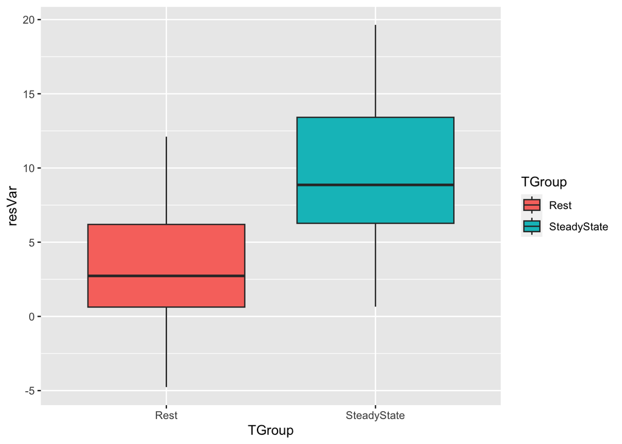

```r
# Plot of ANOVA Data
ANOPlot <- ggplot(data=ANOdata,aes(x=TGroup,y=resVar,fill=TGroup)) +
           geom_boxplot()
print(ANOPlot)
```

```r
# ggsave(filename="Plot2.pdf",plot=ANOPlot,device="pdf")
```

5. Try running your analysis multiple times to get a feeling for how variable the results are with the same parameters, but different sets of random numbers.